# Презентация по лабораторной работе №14

Дисциплина: Архитектура компьютеров и операционные системы

Гусев Степан Андреевич

1032242444@rudn.ru

Российский университет дружбы народов

2026-04-08

# Информация

**Презентация по лабораторной работе №14**

**Автор:** Гусев Степан Андреевич

**Преподаватель:** Кулябов Дмитрий Сергеевич, д.ф.-м.н., профессор кафедры теории вероятностей и кибербезопасности

Российский университет дружбы народов

## Докладчик

- Гусев Степан Андреевич
- Студент программы “Бизнес-информатика”
- Российский университет дружбы народов им. П. Лумумбы
- 1032242444@rudn.ru
- https://github.com/stepagusev

## Цель

Изучить основы программирования в оболочке ОС UNIX. Научится писать более сложные командные файлы с использованием логических управляющих конструкций и циклов.

## Задание

1. Написать командный файл, реализующий упрощённый механизм семафоров. Командный файл должен в течение некоторого времени t1 дожидаться освобождения ресурса, выдавая об этом сообщение, а дождавшись его освобождения, использовать его в течение некоторого времени t2<>t1, также выдавая информацию о том, что ресурс используется соответствующим командным файлом (процессом).
2. Реализовать команду man с помощью командного файла.
3. Используя встроенную переменную $RANDOM, напишите командный файл, генерирующий случайную последовательность букв латинского алфавита.

# Выполнение лабораторной работы

## Первый скрипт

Создал файл 1.sh, дал права на выполнение, ввёл код и запустил скрипт.

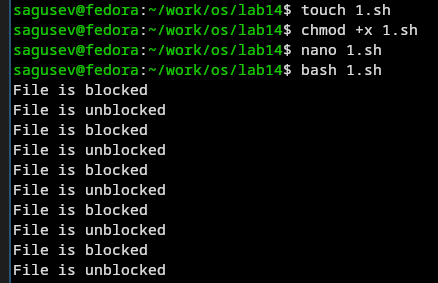

Рисунок 1: Создание файла 1

## Первый скрипт

Текст скрипта 1.sh.

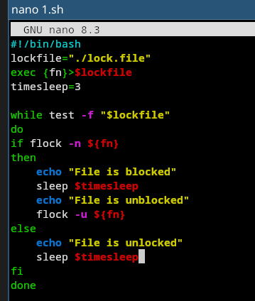

Рисунок 2: Скрипт 1

## Второй скрипт

Изучил содержимое каталога /usr/sher/man/man1.

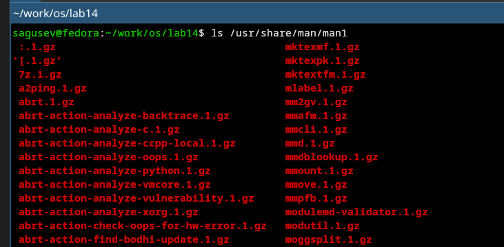

Рисунок 3: Содержимое каталога

## Второй скрипт

Создал файл 2.sh, дал права на выполнение.

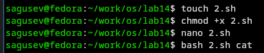

Рисунок 4: Создание файла 2

## Второй скрипт

Текст скрипта 2.sh.

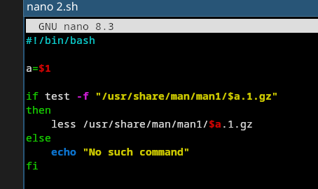

Рисунок 5: Скрипт 2

## Второй скрипт

После запуска открылось окно со справкой для команды cat.

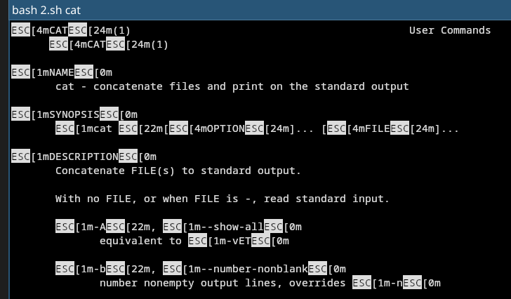

Рисунок 6: Справка cat

## Третий скрипт

Создал файл 3.sh, дал права на выполнение, открыл файл.

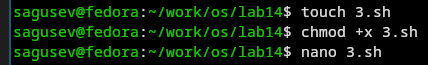

Рисунок 7: Создание файла 3

## Третий скрипт

Ввёл текст скрипта 3.sh.

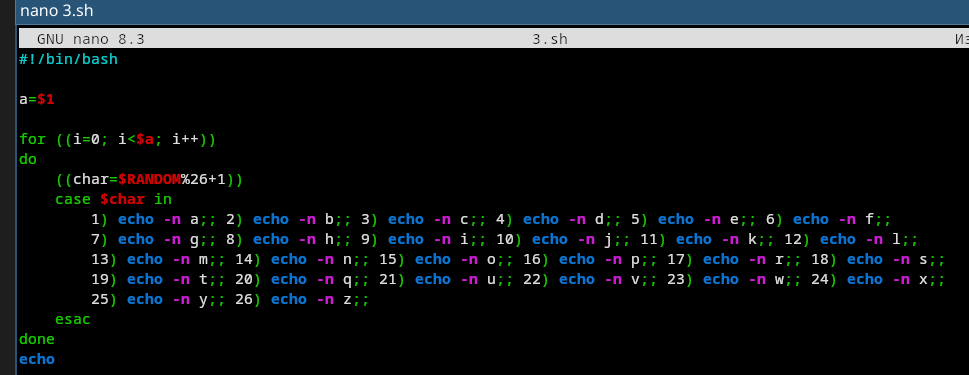

Рисунок 8: Скрипт 3

## Третий скрипт

Запустил скрипт 3 и проверил, что всё сработало корректно.

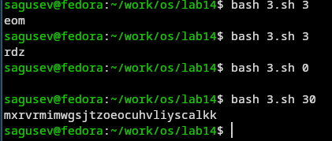

Рисунок 9: Результат работы скрипта 3

# Выводы

## Выводы

Я изучил основы программирования в оболочке ОС UNIX и научился писать более сложные командные файлы с использованием логических управляющих конструкций и циклов.